# Statystyka I z R Warsztat 3. Struktury danych II; rozkłady zmiennych

Tomasz Żółtak

17 października 2016

Na dzisiejszych zajęciach zapoznamy się z używaniem macierzy. Poznamy też funkcję `table()`, przy pomocy której będziemy tworzyć rozkłady zmiennych. Poznamy też sposób tworzenia **prostych** tabel w Rmarkdown i wizualizowania (dyskretnych) rozkładów zmiennych.

# Podstawowe struktury danych w R - macierze

Macierze to dwuwymiarowe struktury danych składające się z elementów tego samego typu. Możemy wykorzystywać je m. in. do reprezentowania macierzy danych, rozkładów łączynych lub rodzin rozkładów warunkowych.

## Tworzenie macierzy

Macierz możemy utworzyć korzystając z funkcji `matrix()`, która jako pierwszy argument przyjmuje wektor wartości, którymi chcemy wypełnić macierz. Liczbę wierszy i kolumn macierzy podajemy korzystając z argumentów odpowiednio `nrow` i `ncol`.

```r
> x = matrix(1:16, nrow = 4)
> x
     [,1] [,2] [,3] [,4]
[1,]    1    5    9   13
[2,]    2    6   10   14
[3,]    3    7   11   15
[4,]    4    8   12   16
> str(x)
 int [1:4, 1:4] 1 2 3 4 5 6 7 8 9 10 ...
> matrix(1:16, nrow = 2)
     [,1] [,2] [,3] [,4] [,5] [,6] [,7] [,8]
[1,]    1    3    5    7    9   11   13   15
[2,]    2    4    6    8   10   12   14   16
> matrix(1:16, ncol = 2)
     [,1] [,2]
[1,]    1    9
[2,]    2   10
[3,]    3   11
[4,]    4   12
[5,]    5   13
[6,]    6   14
[7,]    7   15
[8,]    8   16
```

Zwróćmy uwagę, że macierz wypełniana jest kolejno kolumnami. Gdybyśmy z jakichś powodów chcieli wypełniać ją wierszami, możemy wykorzystać argument `byrow`.

```r
> matrix(letters[1:16], nrow = 2)
     [,1] [,2] [,3] [,4] [,5] [,6] [,7] [,8]
[1,] "a"  "c"  "e"  "g"  "i"  "k"  "m"  "o"
[2,] "b"  "d"  "f"  "h"  "j"  "l"  "n"  "p"
> matrix(letters[1:16], nrow = 2, byrow = TRUE)
     [,1] [,2] [,3] [,4] [,5] [,6] [,7] [,8]
[1,] "a"  "b"  "c"  "d"  "e"  "f"  "g"  "h"
[2,] "i"  "j"  "k"  "l"  "m"  "n"  "o"  "p"
```

Jeśli chcemy całą macierz wypełnić tą samą wartością, wystarczy, że jako pierwszy argument podamy tą pojedynczą wartość (wektor jedoelementowy). O ile nie chcemy uzyskać macierzy 1x1, musimy oczywiście w takim przypadku podać zarówno argument `nrow` jak i `ncol`.

```r
> matrix(10, nrow = 2, ncol = 3)
     [,1] [,2] [,3]
[1,]   10   10   10
[2,]   10   10   10
> matrix(FALSE, nrow = 5, ncol = 3)
      [,1]  [,2]  [,3]
[1,] FALSE FALSE FALSE
[2,] FALSE FALSE FALSE
[3,] FALSE FALSE FALSE
[4,] FALSE FALSE FALSE
[5,] FALSE FALSE FALSE
```

## Nazwy wierszy i kolumn

Wierszom i kolumnom macierzy możemy nadać nazwy, korzystając z funkcji `rownames()` i `colnames()` (możemy też zrobić to w ramach funkcji `matrix()`, ale nie będziemy teraz o tym mówić, jako że wymagałoby to użycia struktury danych, której jeszcze nie poznaliśmy - listy). Wykorzystuje się przy tym nieco dziwaczną składnię:

```r
> x = matrix(1:15, nrow = 5)
> x
     [,1] [,2] [,3]
[1,]    1    6   11
[2,]    2    7   12
[3,]    3    8   13
[4,]    4    9   14
[5,]    5   10   15
> # póki co wiersze ani kolumny macierzy 'x' nie mają żadnych nazw
> rownames(x)
NULL
> colnames(x)
NULL
> # nadajmy im nazwy
> rownames(x) = paste("w", 1:nrow(x), sep = "")
> colnames(x) = paste("k", 1:ncol(x), sep = "")
> # tak wygląda nasza macierz z nazwami wierszy i kolumn
> x
   k1 k2 k3
w1  1  6 11
w2  2  7 12
w3  3  8 13
w4  4  9 14
w5  5 10 15
> rownames(x)
[1] "w1" "w2" "w3" "w4" "w5"
> colnames(x)
[1] "k1" "k2" "k3"
```

## Wybieranie elementów macierzy

Jeśli chcemy wybrać z macierzy pewne elementy, możemy to zrobić analogicznymi metodami jak w przypadku wektorów, tyle że:

1. Indeksowanie odbywa się w dwóch wymiarach.
2. Co do zasady wybieramy *prostokątny* obszar.

Do wybierania służy nam operator `[]`, z tym że w przypadku macierzy przyjmuje on dwa argumenty, oddzielone przecinkiem: `[wektor_wskazujący_które_wybrać, wektor_wskazujący_które_kolumny_wybrać]`.

```r
> x = matrix(1:30, nrow = 5)
> rownames(x) = paste("w", 1:nrow(x), sep = "")
> colnames(x) = paste("k", 1:ncol(x), sep = "")
> x
   k1 k2 k3 k4 k5 k6
w1  1  6 11 16 21 26
w2  2  7 12 17 22 27
w3  3  8 13 18 23 28
w4  4  9 14 19 24 29
w5  5 10 15 20 25 30
> # możemy wybrać tylko niektóre wiersze i/lub kolumny macierzy
> x[2:4, 4:6]
   k4 k5 k6
w2 17 22 27
w3 18 23 28
w4 19 24 29
> x[-c(1, 3, 5), c(TRUE, TRUE, FALSE, TRUE, FALSE, TRUE)]
   k1 k2 k4 k6
w2  2  7 17 27
w4  4  9 19 29
> x[c(5, 1, 2, 4, 3), -5]
   k1 k2 k3 k4 k6
w5  5 10 15 20 30
w1  1  6 11 16 26
w2  2  7 12 17 27
w4  4  9 14 19 29
w3  3  8 13 18 28
> # możemy też oczywiście chcieć wybrać konkretny element
> x[1, 4]
[1] 16
```

Jeśli chcemy wybrać całe rzędy lub całe kolumny, możemy po prostu nie podawać nic jako odpowiedni argumentu operatora `[]`:

```r
> # całe rzędy
> x[2:4, ]
   k1 k2 k3 k4 k5 k6
w2  2  7 12 17 22 27
w3  3  8 13 18 23 28
w4  4  9 14 19 24 29
> x[(x[, 6] %% 2) == 0, ]
   k1 k2 k3 k4 k5 k6
w1  1  6 11 16 21 26
w3  3  8 13 18 23 28
w5  5 10 15 20 25 30
> # całe kolumny
> x[, 5:4]
   k5 k4
w1 21 16
w2 22 17
w3 23 18
w4 24 19
w5 25 20
> x[, x[1, ] > 11]
   k4 k5 k6
w1 16 21 26
w2 17 22 27
w3 18 23 28
w4 19 24 29
w5 20 25 30
```

### Specjalne funkcje dla macierzy kwadratowych

W przypadku macierzy kwadratowych (mających taką samą liczbę wierszy i kolumn) mamy dostępnych kilka funkcji, które pozwalają nam uzyskać łatwy dostęp do pewnych ich fragmentów. Ponieważ fregmenty te nie mają *prostokątnego* kształtu, w efekcie otrzymamy wektory wartości.

1. Elementy leżące na przekątnej możemy uzyskać korzystając z funkcji `diag()`.
2. Elementy poniżej lub powyżej przekątnej - korzystając z funkcji `lower.tri()` i `upper.tri()`.

```r
> y = matrix(1:16, nrow = 4)
> y
     [,1] [,2] [,3] [,4]
[1,]    1    5    9   13
[2,]    2    6   10   14
[3,]    3    7   11   15
[4,]    4    8   12   16
> diag(y)
[1]  1  6 11 16
> y[lower.tri(y)]
[1]  2  3  4  7  8 12
> y[upper.tri(y)]
[1]  5  9 10 13 14 15
```

Póki co funkcje te nie będą mieć dla nas znaczenia.

## Zmiana wartości elementów macierzy

Wartości macierzy możemy zmieniać, wskazując, o które elementy nam chodzi i podając wartości, które mają im zostać przypisane.

```r
> x
   k1 k2 k3 k4 k5 k6
w1  1  6 11 16 21 26
w2  2  7 12 17 22 27
w3  3  8 13 18 23 28
w4  4  9 14 19 24 29
w5  5 10 15 20 25 30
> x[1, 1] = 100
> x
    k1 k2 k3 k4 k5 k6
w1 100  6 11 16 21 26
w2   2  7 12 17 22 27
w3   3  8 13 18 23 28
w4   4  9 14 19 24 29
w5   5 10 15 20 25 30
> x[, 2] = 101:105
> x
    k1  k2 k3 k4 k5 k6
w1 100 101 11 16 21 26
w2   2 102 12 17 22 27
w3   3 103 13 18 23 28
w4   4 104 14 19 24 29
w5   5 105 15 20 25 30
> x[2:3, 3:5] = -1:-6
> x
    k1  k2 k3 k4 k5 k6
w1 100 101 11 16 21 26
w2   2 102 -1 -3 -5 27
w3   3 103 -2 -4 -6 28
w4   4 104 14 19 24 29
w5   5 105 15 20 25 30
```

## Operacje na macierzach

### Proste operacje arytmetyczne

Podobnie jak w przypadku wektorów, wykonanie operacji w rodzaju dodania/odjęcia/pomnożenia/podzielenia przez stałą wykonywane jest w odniesieniu do wszystkich elementów macierzy.

```r
> y = matrix(1, nrow = 3, ncol = 4)
> y
     [,1] [,2] [,3] [,4]
[1,]    1    1    1    1
[2,]    1    1    1    1
[3,]    1    1    1    1
> y - 1
     [,1] [,2] [,3] [,4]
[1,]    0    0    0    0
[2,]    0    0    0    0
[3,]    0    0    0    0
> (2 * y)^2
     [,1] [,2] [,3] [,4]
[1,]    4    4    4    4
[2,]    4    4    4    4
[3,]    4    4    4    4
```

Również analogicznie do wektorów, jeśli dokonamy tego typu operacji na dwóch macierzach o równej sobie liczbie wierszy i równej sobie liczbie kolumn, operacja zostanie wykonana parami na odpowiadających sobie elementach macierzy.

```r
> x = matrix(1, nrow = 3, ncol = 4)
> y = matrix(rep(0:11, 4), nrow = 3, ncol = 4)
> x
     [,1] [,2] [,3] [,4]
[1,]    1    1    1    1
[2,]    1    1    1    1
[3,]    1    1    1    1
> y
     [,1] [,2] [,3] [,4]
[1,]    0    3    6    9
[2,]    1    4    7   10
[3,]    2    5    8   11
> x + y
     [,1] [,2] [,3] [,4]
[1,]    1    4    7   10
[2,]    2    5    8   11
[3,]    3    6    9   12
```

### Najbardziej typowe operacje na całych wierszach i/lub kolumnach

Dwie najbardziej typowe operacje, które wykonuje się na całych wierszach i/lub kolumnach macierzy to obliczenie sumy lub średniej elementów wiersza/kolumny. Pozwalają na to funkcje `rowSums()`, `colSums()`, `rowMeans()` i `colMeans()`.

```r
> x = matrix(rep(1:5, 6), nrow = 5)
> x
     [,1] [,2] [,3] [,4] [,5] [,6]
[1,]    1    1    1    1    1    1
[2,]    2    2    2    2    2    2
[3,]    3    3    3    3    3    3
[4,]    4    4    4    4    4    4
[5,]    5    5    5    5    5    5
> rowSums(x)
[1]  6 12 18 24 30
> rowMeans(x)
[1] 1 2 3 4 5
> colSums(x)
[1] 15 15 15 15 15 15
> colMeans(x)
[1] 3 3 3 3 3 3
```

### Łączenie ze sobą macierzy oraz macierzy i wektorów

Macierze mające taką samą liczbę kolumn możemy połączyć *dostawiając drugą poniżej pierwszej* przy pomocy funkcji `rbind()`. Macierze o takiej samej liczbie wierszy możemy z kolei połączyć *dostawiając drugą po prawej stronie pierwszej* przy pomocy funkcji `cbind()`. Drugim argumentem tych funkcji może też być wektor, o liczbie elementów równej odpowiednio liczbie kolumn lub liczbie wierszy macierzy będącej pierwszym argumentem.

```r
> x = matrix(0, nrow = 2, ncol = 3)
> y = matrix(1, nrow = 3, ncol = 3)
> z = matrix(2, nrow = 2, ncol = 2)
> x
     [,1] [,2] [,3]
[1,]    0    0    0
[2,]    0    0    0
> y
     [,1] [,2] [,3]
[1,]    1    1    1
[2,]    1    1    1
[3,]    1    1    1
> z
     [,1] [,2]
[1,]    2    2
[2,]    2    2
> rbind(x, y)
     [,1] [,2] [,3]
[1,]    0    0    0
[2,]    0    0    0
[3,]    1    1    1
[4,]    1    1    1
[5,]    1    1    1
> cbind(x, z)
     [,1] [,2] [,3] [,4] [,5]
[1,]    0    0    0    2    2
[2,]    0    0    0    2    2
> rbind(y, colSums(y))
     [,1] [,2] [,3]
[1,]    1    1    1
[2,]    1    1    1
[3,]    1    1    1
[4,]    3    3    3
> cbind(z, rowSums(z))
     [,1] [,2] [,3]
[1,]    2    2    4
[2,]    2    2    4
```

### Operacje macierzowe

R posiada też oczywiście zestaw funkcji pozwalających nam wykonać podstawowe operacje algebry macierzy:

- transpozycję - funkcja `t()`,
- mnożenie mcierzowe - operator `%*%`,
- obliczanie odwrotności - funkcja `solve()`.

Podczas tego kursu raczej nie będziemy ich jednak wykorzystywać.

# Rozkłady

```r
> try(setwd("warsztat 2016.10.17"), silent = TRUE)
> nazwyObiektow = load("dane_2016.10.17.RData")
> nazwyObiektow
 [1] "etykiety" "Y"        "X"        "Z"        "W"        "V1"
 [7] "V2"       "V3"       "V4"       "V5"       "V6"       "V7"
> etykiety
                                              Y
                             "Rok badania PGSS"
                                              X
           "Wielkość miejscowości zamieszkania"
                                              Z
          "Liczba osób w gospodarstwie domowym"
                                              W
                             "Wiek respondenta"
                                             V1
           "Zadowolenie z miejsca zamieszkania"
                                             V2
     "Zadowolenie z czasu wolnego i wypoczynku"
                                             V3
               "Zadowolenie z życia rodzinnego"
                                             V4
                      "Zadowolenie z przyjaźni"
                                             V5
                 "Zadowolenie ze stanu zdrowia"
                                             V6
"Zadowolenie ze swoich warunków mieszkaniowych"
                                             V7
         "Zadowolenie z własnego wykształcenia"
> summary(cbind(Y, X, Z, W, V1, V2, V3, V4, V5, V6, V7))
    Y                       X                       Z             W
 1992:198   1 Wieś           :436   1 JEDNA          : 67   21     :134
 1995:221   2 M do 25 tys    :197   2 DWIE           :135   20     :131
 1999:354   3 M 25-99,9 tys  :198   3 TRZY           :323   25     :127
 2005:204   4 M 100-499,9 tys:214   4 CZTERY         :291   27     :124
 2010:218   5 M 500+ tys     :150   5 PIĘĆ           :167   28     :123
                                    6 SZEŚĆ          :122   26     :120
                                    7 SIEDEM I WIĘCEJ: 90   (Other):436
                      V1                           V2
 1 Bardzo zadowolony   :228   1 Bardzo zadowolony   :139
 2 Zadowolony          :535   2 Zadowolony          :436
 3 Raczej zadowolony   :286   3 Raczej zadowolony   :309
 4 Raczej niezadowolony: 79   4 Raczej niezadowolony:182
 5 Niezadowolony       : 52   5 Niezadowolony       : 99
 6 Bardzo niezadowolony: 15   6 Bardzo niezadowolony: 30

                      V3                           V4
 1 Bardzo zadowolony   :344   1 Bardzo zadowolony   :290
 2 Zadowolony          :598   2 Zadowolony          :624
 3 Raczej zadowolony   :192   3 Raczej zadowolony   :228
 4 Raczej niezadowolony: 37   4 Raczej niezadowolony: 34
 5 Niezadowolony       : 13   5 Niezadowolony       : 18
 6 Bardzo niezadowolony: 11   6 Bardzo niezadowolony:  1

                      V5                           V6
 1 Bardzo zadowolony   :272   1 Bardzo zadowolony   :149
 2 Zadowolony          :609   2 Zadowolony          :450
 3 Raczej zadowolony   :199   3 Raczej zadowolony   :287
 4 Raczej niezadowolony: 78   4 Raczej niezadowolony:128
 5 Niezadowolony       : 28   5 Niezadowolony       :120
 6 Bardzo niezadowolony:  9   6 Bardzo niezadowolony: 61

                      V7
 1 Bardzo zadowolony   :162
 2 Zadowolony          :520
 3 Raczej zadowolony   :239
 4 Raczej niezadowolony:161
 5 Niezadowolony       : 95
 6 Bardzo niezadowolony: 18
```

## Funkcja table()

### Rozkład brzegowy liczebności

Aby uzyskać **rozkład liczebności**, najprościej posłużyć się funkcją `table()`. Możemy wywołać ją z jednym argumentem, uzyskując rozkład brzegowy danej zmiennej.

```r
> # rozkład wielkości miejscowości zamieszkania w analizowanej zbiorowości
> nX = table(X)
> nX
X
           1 Wieś     2 M do 25 tys   3 M 25-99,9 tys 4 M 100-499,9 tys
              436               197               198               214
     5 M 500+ tys
              150
> str(nX)
 'table' int [1:5(1d)] 436 197 198 214 150
 - attr(*, "dimnames")=List of 1
  ..$ X: chr [1:5] "1 Wieś" "2 M do 25 tys" "3 M 25-99,9 tys" "4 M 100-499,9 tys" ...
```

Zwrócony obiekt jest typu *table*, ale w pratyce możemy postępować z nim analogicznie jak z wektorem, którego elementom zostały przypisane nazwy.

```r
> nX
X
           1 Wieś     2 M do 25 tys   3 M 25-99,9 tys 4 M 100-499,9 tys
              436               197               198               214
     5 M 500+ tys
              150
> names(nX)
[1] "1 Wieś"            "2 M do 25 tys"     "3 M 25-99,9 tys"
[4] "4 M 100-499,9 tys" "5 M 500+ tys"
> nX[2:4]
X
    2 M do 25 tys   3 M 25-99,9 tys 4 M 100-499,9 tys
              197               198               214
> nX[names(nX) == "2 M do 25 tys"]
2 M do 25 tys
          197
> nX * 2
X
           1 Wieś     2 M do 25 tys   3 M 25-99,9 tys 4 M 100-499,9 tys
              872               394               396               428
     5 M 500+ tys
              300
```

Aby obejrzeć rozkład w formie, do jakiej jesteśmy nieco bardziej przyzwyczajeni, możemy użyć funkcji `as.matrix()`.

```r
> mNX = as.matrix(nX)
> colnames(mNX) = "N(X = X_i)"
> mNX
                  N(X = X_i)
1 Wieś                   436
2 M do 25 tys            197
3 M 25-99,9 tys          198
4 M 100-499,9 tys        214
5 M 500+ tys             150
```

W stosunku do tego, jak przywykliśmy opisywać rozkłady w tabelach brakuje jeszcze jednego elementu - sumy wszystkich obserwacji. Możemy ją dodać na dwa sposoby - *ręcznie*, lub przy pomocy funkcji `addmargins()`.

```r
> # "ręcznie"
> c(nX, "suma" = sum(nX))
           1 Wieś     2 M do 25 tys   3 M 25-99,9 tys 4 M 100-499,9 tys
              436               197               198               214
     5 M 500+ tys              suma
              150              1195
> ## analogicznie do rozkładu w formie macierzy
> rbind(mNX, "suma" = sum(mNX))
                  N(X = X_i)
1 Wieś                   436
2 M do 25 tys            197
3 M 25-99,9 tys          198
4 M 100-499,9 tys        214
5 M 500+ tys             150
suma                    1195
> # przy pomocy funkcji addmargins()
> addmargins(nX)
X
           1 Wieś     2 M do 25 tys   3 M 25-99,9 tys 4 M 100-499,9 tys
              436               197               198               214
     5 M 500+ tys               Sum
              150              1195
> ## w przypadku macierzy musimy podać dodatkowy argument, wskazujący, w którą
> ##   stronę ma zostać dokonane zliczanie (1 - w pionie, 2 - w poziomie)
> addmargins(mNX, 1)
                  N(X = X_i)
1 Wieś                   436
2 M do 25 tys            197
3 M 25-99,9 tys          198
4 M 100-499,9 tys        214
5 M 500+ tys             150
Sum                     1195
```

### Rozkład brzegowy częstości

Aby uzyskać **rozkład częstości**, musimy podzielić liczebności w poszczególnych komórkach przez liczbę wszystkich obserwacji. Podobnie jak w przypadku dodawania komórki z sumą wszystkich obserwacji, możemy to zrobić *ręcznie*, lub korzystając z gotowej funkcji - w tym przypadku `prop.table()` (uwaga - jej argumentem jest wynik działania funkcji `table()`, a nie surowe dane).

```r
> # "ręcznie"
> nX
X
           1 Wieś     2 M do 25 tys   3 M 25-99,9 tys 4 M 100-499,9 tys
              436               197               198               214
     5 M 500+ tys
              150
> pX = nX / sum(nX)
> pX
X
           1 Wieś     2 M do 25 tys   3 M 25-99,9 tys 4 M 100-499,9 tys
        0.3648536         0.1648536         0.1656904         0.1790795
     5 M 500+ tys
        0.1255230
> # przy pomocy funkcji prop.table()
> pX = prop.table(nX)
> pX
X
           1 Wieś     2 M do 25 tys   3 M 25-99,9 tys 4 M 100-499,9 tys
        0.3648536         0.1648536         0.1656904         0.1790795
     5 M 500+ tys
        0.1255230
> # dalej możemy nadać rozkładowi nieco ładniejszy wygląd
> mPX = as.matrix(c(pX, "suma" = sum(pX)))
> colnames(mPX) = "P(X = x_i)"
> mPX
                  P(X = x_i)
1 Wieś             0.3648536
2 M do 25 tys      0.1648536
3 M 25-99,9 tys    0.1656904
4 M 100-499,9 tys  0.1790795
5 M 500+ tys       0.1255230
suma               1.0000000
```

Uwaga, **jeśli w obiekcie mamy rozkład z dopisanym elementem *sumy*,** musimy oczywiście dzielić przez wartość tego elementu (względnie wartość wszystkich komórek rozkładu poza tą opisującą sumę).

```r
> nXS = c(nX, "suma" = sum(nX))
> nXS
           1 Wieś     2 M do 25 tys   3 M 25-99,9 tys 4 M 100-499,9 tys
              436               197               198               214
     5 M 500+ tys              suma
              150              1195
> # "ręcznie" (w tym przypadku to nawet prościej!)
> pXS = nXS / nXS[length(nXS)]
> pXS
           1 Wieś     2 M do 25 tys   3 M 25-99,9 tys 4 M 100-499,9 tys
        0.3648536         0.1648536         0.1656904         0.1790795
     5 M 500+ tys              suma
        0.1255230         1.0000000
> # przy pomocy funkcji prop.table()
> pXS = prop.table(nXS[-length(nXS)])
> pXS = c(pXS, "suma" = sum(pXS))
> pXS
           1 Wieś     2 M do 25 tys   3 M 25-99,9 tys 4 M 100-499,9 tys
        0.3648536         0.1648536         0.1656904         0.1790795
     5 M 500+ tys              suma
        0.1255230         1.0000000
> # !!! źle !!!
> nXS / sum(nXS)  # !!! źle !!!
           1 Wieś     2 M do 25 tys   3 M 25-99,9 tys 4 M 100-499,9 tys
       0.18242678        0.08242678        0.08284519        0.08953975
     5 M 500+ tys              suma
       0.06276151        0.50000000
> prop.table(nXS)  # !!! źle !!!
           1 Wieś     2 M do 25 tys   3 M 25-99,9 tys 4 M 100-499,9 tys
       0.18242678        0.08242678        0.08284519        0.08953975
     5 M 500+ tys              suma
       0.06276151        0.50000000
> # !!! źle !!!
```

### Skumulowane rozkłady brzegowe

Aby obliczyć **skumulowany rozkład brzegowy liczebności**, najprościej posłużyć się funkcją `cumsum()`. Przyjmuje ona jako argument wektor i zwraca wektor tej samej długości, którego kolejne elementy przyjmują wartości równe sumie wartości elementów wektora wejściowego, od pierwszego do danego.

```r
> rbind("x" = 0:6, "cumsum(x)" = cumsum(0:6))
          [,1] [,2] [,3] [,4] [,5] [,6] [,7]
x            0    1    2    3    4    5    6
cumsum(x)    0    1    3    6   10   15   21
```

#### Zadanie

Dysponując brzegowym rozkładem liczebności zmiennej *X*, zapisanym w obiekcie `nX` oblicz **skumulowany rozkład liczebności** zmiennej *X* i przypisz go do obiektu `sNX`, a następnie **skumulowany rozkład częstości** tej samej zmiennej i przypisz go do obiektu `sPX`.

```r
> nX = table(X)
> nX
X
           1 Wieś     2 M do 25 tys   3 M 25-99,9 tys 4 M 100-499,9 tys
              436               197               198               214
     5 M 500+ tys
              150
> # to jest miejsce na Twój kod
>
>
>
```

### Rozkłady łączne dwóch zmiennych

Funkcja `table()` pozwala też łatwo uzyskać **łączny rozkład liczebności** dwóch zmiennych - wystarczy podać jej jako drugi argument inny wektor (o tej samej liczbie elementów, co ten, który podajemy jako pierwszy argument).

```r
> # łączny rozkład liczebności zadowolenia z własnego wykształcenia
> #   i roku przeprowadzenia badania PGSS
> nV7Y = table(V7, Y)
> nV7Y
                        Y
V7                       1992 1995 1999 2005 2010
  1 Bardzo zadowolony      15   18   34   38   57
  2 Zadowolony             97   96  149   79   99
  3 Raczej zadowolony      40   40   79   44   36
  4 Raczej niezadowolony   27   34   58   25   17
  5 Niezadowolony          17   27   29   14    8
  6 Bardzo niezadowolony    2    6    5    4    1
```

Zwrócony obiekt, jak w przypadku jednowymiarowym, jest typu *table*, ale tym razem ma dwa wymiary i możemy go traktować podobnie jak macierz.

```r
> str(nV7Y)
 'table' int [1:6, 1:5] 15 97 40 27 17 2 18 96 40 34 ...
 - attr(*, "dimnames")=List of 2
  ..$ V7: chr [1:6] "1 Bardzo zadowolony" "2 Zadowolony" "3 Raczej zadowolony" "4 Raczej niezadowolony" ...
  ..$ Y : chr [1:5] "1992" "1995" "1999" "2005" ...
> colnames(nV7Y)
[1] "1992" "1995" "1999" "2005" "2010"
> rownames(nV7Y)
[1] "1 Bardzo zadowolony"    "2 Zadowolony"
[3] "3 Raczej zadowolony"    "4 Raczej niezadowolony"
[5] "5 Niezadowolony"        "6 Bardzo niezadowolony"
> nV7Y[3:4, 2:3]
                        Y
V7                       1995 1999
  3 Raczej zadowolony      40   79
  4 Raczej niezadowolony   34   58
```

Do uzyskanego rozkładu możemy też dodać rozkłady brzegowe, przy pomocy poznanej już wcześniej funkcji `addmargins()`. Wywołanie jej bez podania drugiego parametru spowoduje dodanie wszystkich możliwych (tu: dwóch) rozkładów brzegowych. Możemy też zrobić to *na piechotę*, korzystając z funkcji `rowSums()`, `colSums()`, `rbind()` i `cbind()`.

```r
> # przy pomocy funkcji addmargins()
> addmargins(nV7Y)
                        Y
V7                       1992 1995 1999 2005 2010  Sum
  1 Bardzo zadowolony      15   18   34   38   57  162
  2 Zadowolony             97   96  149   79   99  520
  3 Raczej zadowolony      40   40   79   44   36  239
  4 Raczej niezadowolony   27   34   58   25   17  161
  5 Niezadowolony          17   27   29   14    8   95
  6 Bardzo niezadowolony    2    6    5    4    1   18
  Sum                     198  221  354  204  218 1195
> # "na piechotę"
> nBV7Y = rbind(nV7Y, "suma" = colSums(nV7Y))
> nBV7Y = cbind(nBV7Y, "suma" = rowSums(nBV7Y))
> nBV7Y
                       1992 1995 1999 2005 2010 suma
1 Bardzo zadowolony      15   18   34   38   57  162
2 Zadowolony             97   96  149   79   99  520
3 Raczej zadowolony      40   40   79   44   36  239
4 Raczej niezadowolony   27   34   58   25   17  161
5 Niezadowolony          17   27   29   14    8   95
6 Bardzo niezadowolony    2    6    5    4    1   18
suma                    198  221  354  204  218 1195
```

#### Zadanie

Dysponując łącznym rozkładem liczebności zmiennych *V7* i *Y*, zapisanym w obiekcie `nV7Y` oblicz **łączny rozkład częstości** tych zmiennych i przypisz go do obiektu `pV7Y`. Pokaż ten rozkład w konsoli z wartościami zaokrąglonymi do trzeciego miejsca po przecinku, używając polecenia `round(pV7Y, 3)`.

```r
> # to jest miejsce na Twój kod
>
>
>
>
```

### Rozkłady warunkowe

**Warunkowe rozkłady liczebności** w istocie możemy traktować po prostu jako *wycinki* z łącznego rozkładu liczebności.

```r
> # warunkowy rozkład liczebności zadowolenia z własnego wykształcenia
> #   dla roku badania PGSS równego 1995
> nV7Y[, colnames(nV7Y) == "1995"]
   1 Bardzo zadowolony           2 Zadowolony    3 Raczej zadowolony
                    18                     96                     40
4 Raczej niezadowolony        5 Niezadowolony 6 Bardzo niezadowolony
                    34                     27                      6
> # warunkowy rozkład liczebności zadowolenia z własnego wykształcenia
> #   dla roku badania PGSS mniejszego niż 2000
> temp = nV7Y[, as.numeric(colnames(nV7Y)) < 2000]
> temp
                        Y
V7                       1992 1995 1999
  1 Bardzo zadowolony      15   18   34
  2 Zadowolony             97   96  149
  3 Raczej zadowolony      40   40   79
  4 Raczej niezadowolony   27   34   58
  5 Niezadowolony          17   27   29
  6 Bardzo niezadowolony    2    6    5
> rowSums(temp)
   1 Bardzo zadowolony           2 Zadowolony    3 Raczej zadowolony
                    67                    342                    159
4 Raczej niezadowolony        5 Niezadowolony 6 Bardzo niezadowolony
                   119                     73                     13
```

**Rodzina warunkowych rozkładów liczebności** jest z kolei właściwie tożsama, z łącznym rozkładem liczebności, z którego *obcięto* rozkład brzegowy jednej zmiennej.

```r
> # łączny rozkład liczebności zadowolenia z własnego wykształcenia
> #   i roku badania PGSS
> addmargins(nV7Y)
                        Y
V7                       1992 1995 1999 2005 2010  Sum
  1 Bardzo zadowolony      15   18   34   38   57  162
  2 Zadowolony             97   96  149   79   99  520
  3 Raczej zadowolony      40   40   79   44   36  239
  4 Raczej niezadowolony   27   34   58   25   17  161
  5 Niezadowolony          17   27   29   14    8   95
  6 Bardzo niezadowolony    2    6    5    4    1   18
  Sum                     198  221  354  204  218 1195
> # rodzina warunkowych rozkładów liczebności zadowolenia z własnego wykształcenia
> #   pod warunkiem roku badania PGSS
> addmargins(nV7Y)[, -(ncol(nV7Y) + 1)]
                        Y
V7                       1992 1995 1999 2005 2010
  1 Bardzo zadowolony      15   18   34   38   57
  2 Zadowolony             97   96  149   79   99
  3 Raczej zadowolony      40   40   79   44   36
  4 Raczej niezadowolony   27   34   58   25   17
  5 Niezadowolony          17   27   29   14    8
  6 Bardzo niezadowolony    2    6    5    4    1
  Sum                     198  221  354  204  218
> # lub równoważnie (a nawet prościej)
> addmargins(nV7Y, 1)
                        Y
V7                       1992 1995 1999 2005 2010
  1 Bardzo zadowolony      15   18   34   38   57
  2 Zadowolony             97   96  149   79   99
  3 Raczej zadowolony      40   40   79   44   36
  4 Raczej niezadowolony   27   34   58   25   17
  5 Niezadowolony          17   27   29   14    8
  6 Bardzo niezadowolony    2    6    5    4    1
  Sum                     198  221  354  204  218
```

Pojedynczy **warunkowy rozkład częstości** możemy uzyskać na podstawie odpowiedniego warunkowego rozkładu liczebności w analogiczny sposób, jak brzegowy rozkład częstości na podstawie brzegowego rozkładu liczebności.

```r
> # jakiś rozkład warunkowy
> nWarunkowyV7Y1995 = nV7Y[, colnames(nV7Y) == "1995"]
> nWarunkowyV7Y1995
   1 Bardzo zadowolony           2 Zadowolony    3 Raczej zadowolony
                    18                     96                     40
4 Raczej niezadowolony        5 Niezadowolony 6 Bardzo niezadowolony
                    34                     27                      6
> # "ręcznie"
> pWarunkowyV7Y1995 = nWarunkowyV7Y1995 / sum(nWarunkowyV7Y1995)
> pWarunkowyV7Y1995
   1 Bardzo zadowolony           2 Zadowolony    3 Raczej zadowolony
            0.08144796             0.43438914             0.18099548
4 Raczej niezadowolony        5 Niezadowolony 6 Bardzo niezadowolony
            0.15384615             0.12217195             0.02714932
> # przy pomocy funkcji prop.table
> prop.table(nWarunkowyV7Y1995)
   1 Bardzo zadowolony           2 Zadowolony    3 Raczej zadowolony
            0.08144796             0.43438914             0.18099548
4 Raczej niezadowolony        5 Niezadowolony 6 Bardzo niezadowolony
            0.15384615             0.12217195             0.02714932
```

**Pamiętamy oczywiście o tym, że w sytuacji, gdy do nasz rozkład łączny już wcześniej uzupełniliśmy o rozkłady brzegowe, musielibyśmy obliczyć to nieco inaczej!**

**Rodzinę warunkowych rozkładów częstości** również możemy uzyskać przy pomocy funkcji `prop.table()`, podając jej drugi (opcjonalny), argument. Podobnie jak w przypadku funkcji `addmargins()` wskazuje on, *w którą stronę* ma być wykonana operacja (tu: procentowania). Żeby sprawy nie były zbyt proste, **wartości tego drugiego argumentu mają inne znaczenie w ramach funkcji `prop.table()`, niż w ramach funkcji `addmargins()`**:

- `prop.table()`: 1 - procentuj w wierszach, 2 - procentuj w kolumnach;
- `addmargins()`: 1 - dodaj rozkład brzegowy pierwszej zmiennej (dla dwóch zmiennych: ten na dole, tzn. sumuj w kolumnach), 2 - dodaj rozkład brzegowy drugiej zmienej (dla dwóch zmiennych: ten po prawej, tzn. sumuj w wierszach).

```r
> # rodzina warunkowych rozkładów częstości zadowolenia z własnego wykształcenia
> #   w zależności od roku badania PGSS
> rWRPV7Y = addmargins(prop.table(nV7Y, 2), 1)
> rWRPV7Y
                        Y
V7                              1992        1995        1999        2005
  1 Bardzo zadowolony    0.075757576 0.081447964 0.096045198 0.186274510
  2 Zadowolony           0.489898990 0.434389140 0.420903955 0.387254902
  3 Raczej zadowolony    0.202020202 0.180995475 0.223163842 0.215686275
  4 Raczej niezadowolony 0.136363636 0.153846154 0.163841808 0.122549020
  5 Niezadowolony        0.085858586 0.122171946 0.081920904 0.068627451
  6 Bardzo niezadowolony 0.010101010 0.027149321 0.014124294 0.019607843
  Sum                    1.000000000 1.000000000 1.000000000 1.000000000
                        Y
V7                              2010
  1 Bardzo zadowolony    0.261467890
  2 Zadowolony           0.454128440
  3 Raczej zadowolony    0.165137615
  4 Raczej niezadowolony 0.077981651
  5 Niezadowolony        0.036697248
  6 Bardzo niezadowolony 0.004587156
  Sum                    1.000000000
> round(rWRPV7Y, 3)
                        Y
V7                        1992  1995  1999  2005  2010
  1 Bardzo zadowolony    0.076 0.081 0.096 0.186 0.261
  2 Zadowolony           0.490 0.434 0.421 0.387 0.454
  3 Raczej zadowolony    0.202 0.181 0.223 0.216 0.165
  4 Raczej niezadowolony 0.136 0.154 0.164 0.123 0.078
  5 Niezadowolony        0.086 0.122 0.082 0.069 0.037
  6 Bardzo niezadowolony 0.010 0.027 0.014 0.020 0.005
  Sum                    1.000 1.000 1.000 1.000 1.000
```

## Prosta wizualizacja rozkładów zmiennych (kategorialnych) - funkcja barplot()

### Prosta wizualizacja rozkładu jednej zmiennej

Wykres słupkowy obrazujący rozkład jednej zmiennej możemy uzyskać korzystając z funkcji `barplot`, której jako argument podajemy rozkład danej zmiennej (uwaga, bez ew. elementu z sumą).

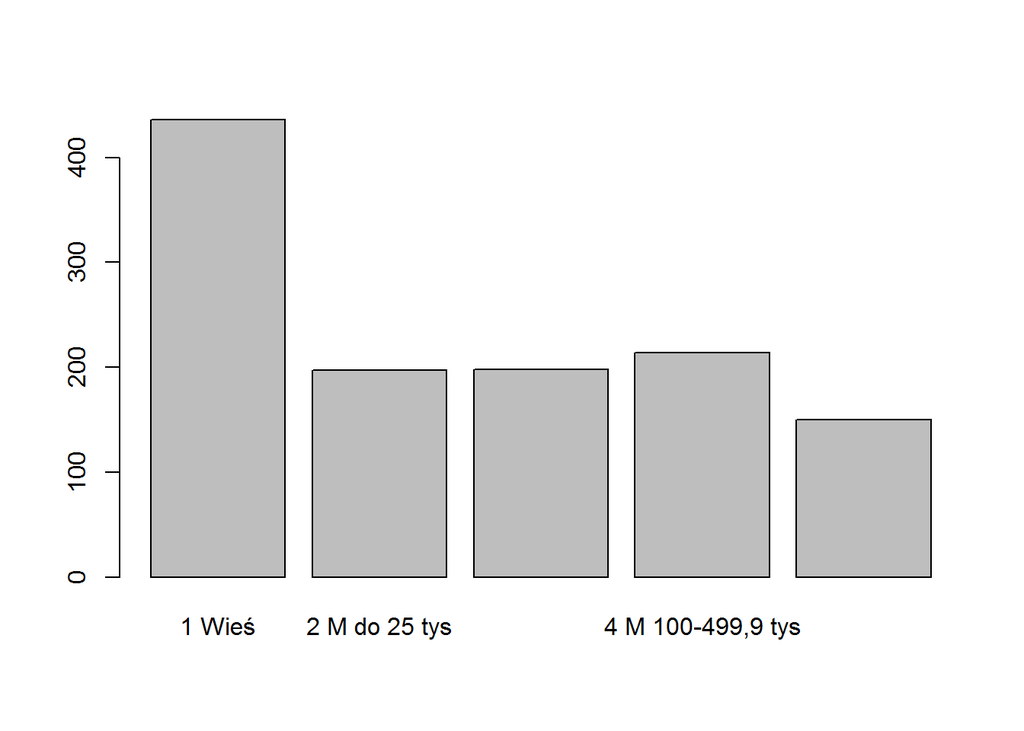

```r
> nX = table(X)
> pX = prop.table(nX)
> barplot(nX)
```

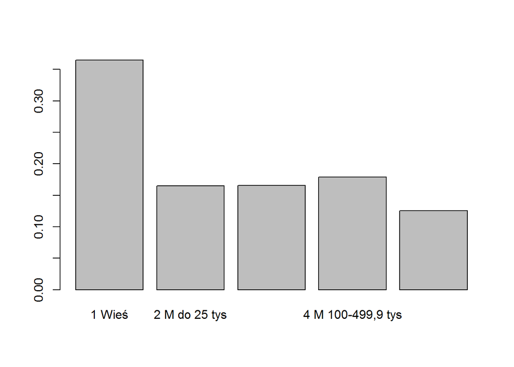

```r
> barplot(pX)
```

Funkcja ma też dużą liczbę dodatkowych argumentów, które pozwalają nam zarządzać jego wyglądem i uzupełnić o dodatkowe elmenty (np. tytuł, czy etykiety osi). Funkcji `grid()` możemy użyć, aby dodać linie siatki.

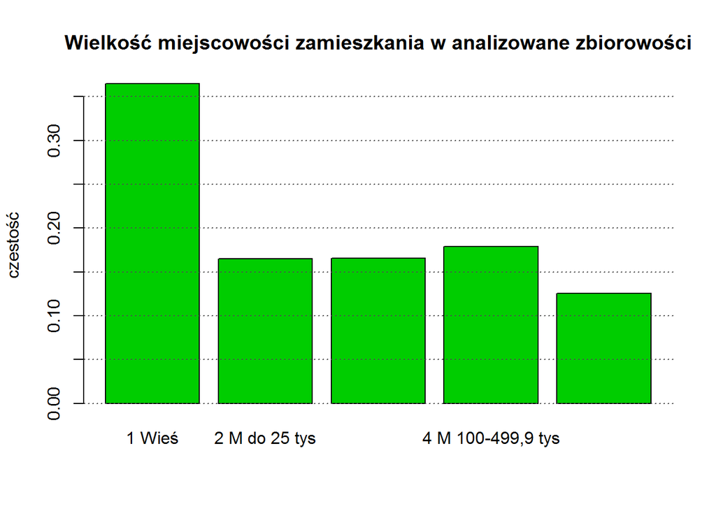

```r
> barplot(pX, col = 3,
+         main = "Wielkość miejscowości zamieszkania w analizowane zbiorowości",
+         ylab = "czestość")
> grid(col = grey(0.3), nx = NA, ny = NULL)
```

Czasem bardziej użyteczne byłoby pokazanie wykresu w postaci *skumulowanej* - słupków reprezentujących częstość (względnie liczebność) poszczególnych słupków *nałożonych jeden na drugim*. Możemy to łatwo uzyskać, konwertując nasz rozkład na macierz przed przekazaniem funkcji `barplot()`.

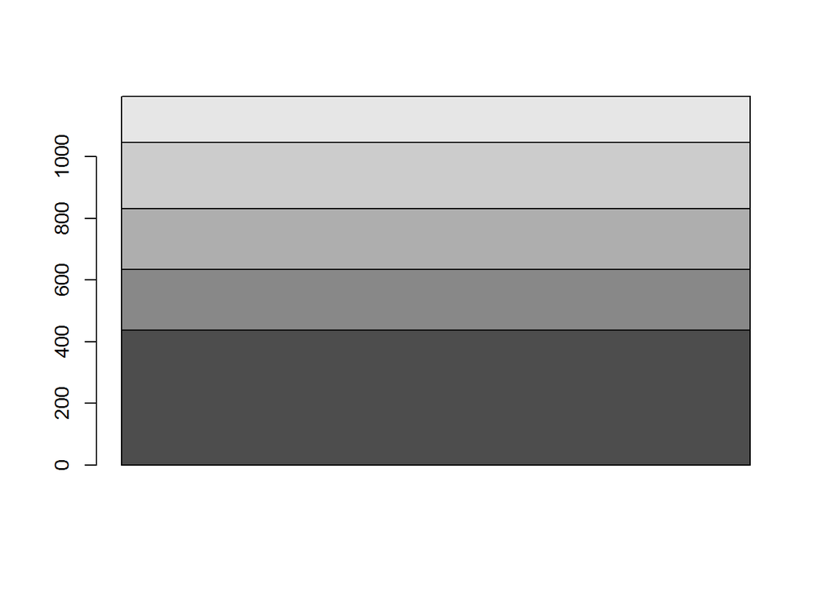

```r
> barplot(as.matrix(nX))
```

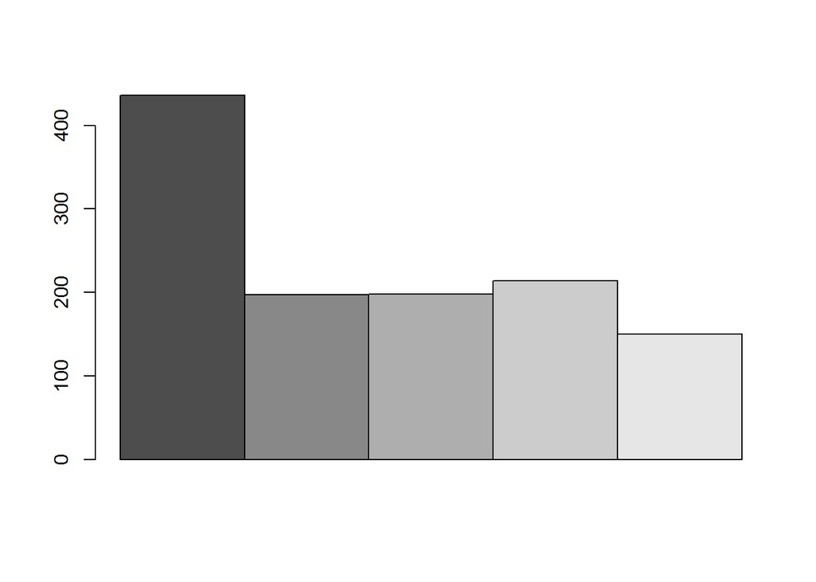

```r
> # nawet mając macierz możemy wrócić do poprzedniego wyglądu
> barplot(as.matrix(nX), beside = TRUE)
```

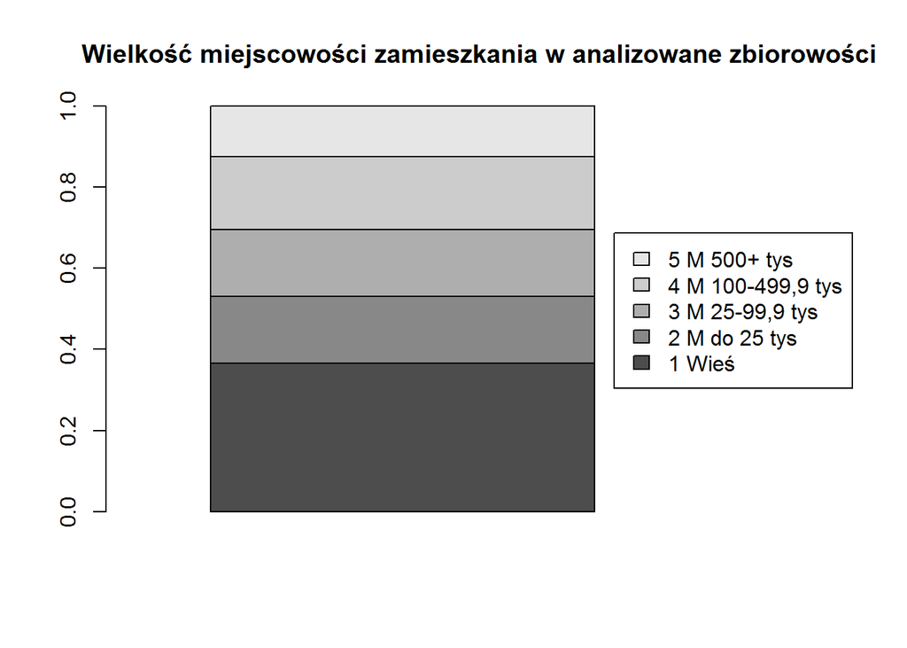

```r
> # żeby móc coś zrozumieć, warto dodać legendę
> barplot(as.matrix(pX),
+         main = "Wielkość miejscowości zamieszkania w analizowane zbiorowości",
+         legend.text = TRUE, args.legend =  list(x = "right"), xlim = c(0, 1.8))
```

Niestety kwestia pozycjonowania legendy nie jest tu rozwiązana w niezawodny sposób.

### Prosta wizualizacja rozkładu dwóch zmiennych

Opisane poniżej rozwiązania można oczywiście zastosować do różnych typów rozkładów łącznych i rodzin rozkładów warunkowych, ale **prowadząc analizy zwykle skupiamy się na porównywania ze sobą rozkładów w ramach rodziny warunkowych rozkładów częstości**. Stąd przykład odnosi się właśnie do takiej rodziny rozkładów.

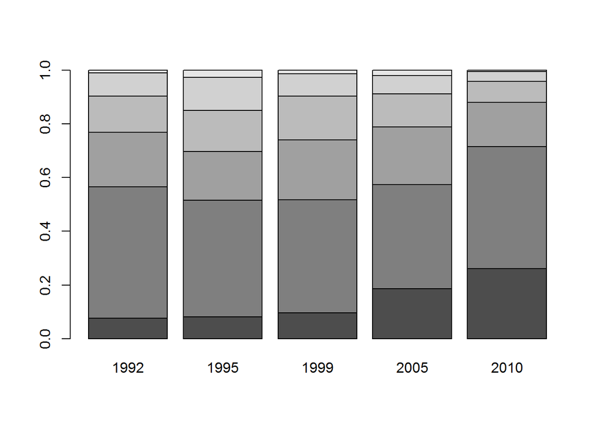

```r
> # rodzina warunkowych rozkładów częstości zadowolenia z własnego wykształcenia
> #   w zależności od roku badania PGSS
> rWRPV7Y = prop.table(nV7Y, 2)
> barplot(rWRPV7Y)
```

Bez legendy, tytułu i etykiet osi trochę trudno się zorientować, o co chodzi.

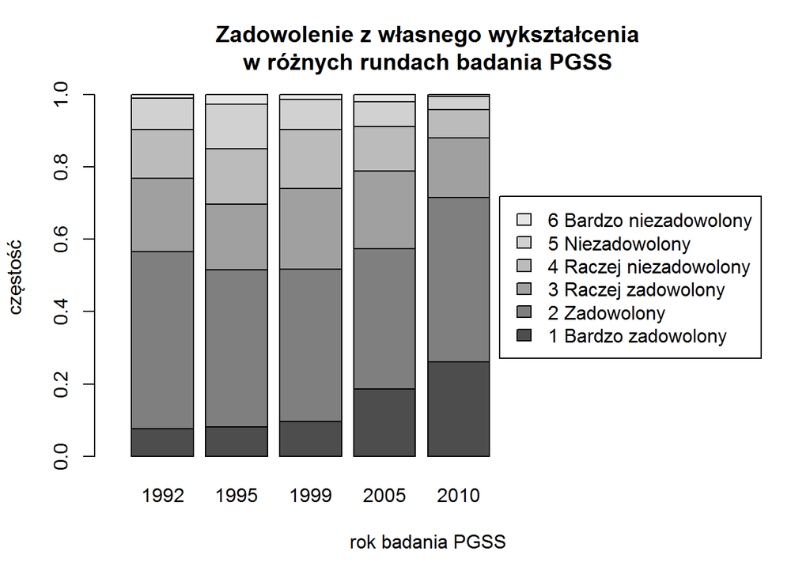

```r
> barplot(rWRPV7Y,
+         main = "Zadowolenie z własnego wykształcenia\nw różnych rundach badania PGSS",
+         xlab = "rok badania PGSS",
+         ylab = "częstość",
+         legend.text = TRUE, args.legend =  list(x = "right"), xlim = c(0, 10))
```

Możemy też uzyskać wykres w postaci słupków zestawionych obok siebie - choć w tym przypadku jest on raczej mniej użyteczny analitycznie.

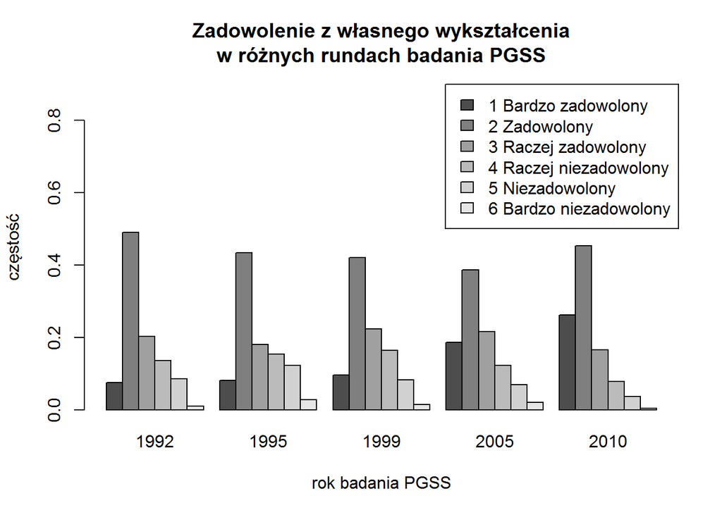

```r
> barplot(rWRPV7Y, beside = TRUE,
+         main = "Zadowolenie z własnego wykształcenia\nw różnych rundach badania PGSS",
+         xlab = "rok badania PGSS",
+         ylab = "częstość",
+         legend.text = TRUE, args.legend =  list(x = "topright"), ylim = c(0, 0.9))
```

# Na następne zajęcia

## Praca domowa

Wejdź dziś wieczorem na stronę projektu na GitHubie z materiałami z tego warsztatu i zobacz, co pojawiło się w tym miejscu.

## Do przeczytania na następne zajęcia

[G. Lissowski, J. Haman i M. Jasiński. (2011). Podstawy statystyki dla socjologów. Wyd. II poprawione. Warszawa: Wydawnictwo Naukowe SCHOLAR.](http://libra.ibuk.pl/book/145985) - Rozdziały: 1.1.-1.2., 3.5.-3.6., 4.1.-4.2. oraz 4.5. w zakresie, w jakim odnosi się do parametrów omówionych w 4.1. i 4.2.